# Programming language

# Ⅰ. introduction

## ● Calculate

1. **" + "** 加；**" - "** 減
2. **" * "** 乘；**" / "** 除
3. **" ^ "** or **" sqrt() "** 次方
4. **" %/% "** 商；**" %% "** 餘數
5. **" abs() "** 絕對值
6. **" exp() "** exponential
7. **" log(x,base=exp(1)) "**

## ● Approximated values

1. **" round(x,digits=n) "** 去掉小數的部分且進位,n為設定留下的位數

```r
round(125.78253,digits=3);round(125.78253,digits=-2)
```

```
## [1] 125.783
```

```
## [1] 100
```

```r
signif(83524587,digits=3);signif(83524587,digits=5)
```

```
## [1] 83500000
```

```
## [1] 83525000
```

3. **" floor(x) "** 無條件捨去 = **" trunc(x) "**

   **" ceiling(x) "** 四捨五入

## ● Related to descriptive statistics

1. mean(x,na.rm=FALSE)
2. var(x,na.rm=FALSE)
3. median(x,na.rm=FALSE)
4. quantile(x, probs = c(),na.rm=FALSE)

```r
x<-1:25
quantile(x,0.5);quantile(x,c(0.1,0.5,0.7))
```

```
## 50%
##  13
```

```
##  10%  50%  70%
##  3.4 13.0 17.8
```

5. summary(x)

```r
summary(x)
```

```
##    Min. 1st Qu.  Median    Mean 3rd Qu.    Max.
##       1       7      13      13      19      25
```

## ● Special values in R

- NA (缺失值)

```r
NA
```

```
## [1] NA
```

- NaN (非數值)

```r
0/0
```

```
## [1] NaN
```

- Inf (無窮大)
- -Inf

```r
2/0
```

```
## [1] Inf
```

```r
-2/0
```

```
## [1] -Inf
```

- pi

```r
pi
```

```
## [1] 3.141593
```

- 1e-3

```r
1e-3
```

```
## [1] 0.001
```

```r
Inf+100
```

```
## [1] Inf
```

```r
Inf-Inf+10
```

```
## [1] NaN
```

```r
NaN+Inf
```

```
## [1] NaN
```

```r
NA+Inf
```

```
## [1] NA
```

```r
NaN+NA
```

```
## [1] NaN
```

## ● Objects

```r
x<-1:25
y<-3
z<-"k"
objects()
```

```
## [1] "x" "y" "z"
```

=ls() (不是is)

```r
ls()
```

```
## [1] "x" "y" "z"
```

If you want to delete some objects,you can type rm()

```r
rm(y,z)
objects()
```

```
## [1] "x"
```

# Ⅱ. Vector

## ● Numeric vector

1. creating a vector

- c()

```r
a<-c(1:5)
b<-c(9:13)
b<-c(a,b)
b
```

```
##  [1]  1  2  3  4  5  9 10 11 12 13
```

- seq()、rep()

```r
seq(1,10,by=3) ## by 公差
```

```
## [1]  1  4  7 10
```

```r
seq(1,10,length.out = 3)
```

```
## [1]  1.0  5.5 10.0
```

```r
rep(3,12)
```

```
##  [1] 3 3 3 3 3 3 3 3 3 3 3 3
```

```r
rep(seq(2,10,2),2)
```

```
##  [1]  2  4  6  8 10  2  4  6  8 10
```

```r
rep(c(1,4),c(3,2))
```

```
## [1] 1 1 1 4 4
```

```r
rep(seq(2,10,2),rep(3,5))
```

```
##  [1]  2  2  2  4  4  4  6  6  6  8  8  8 10 10 10
```

```r
(1:5)+rep((0:4),rep(5,5))
```

```
##  [1] 1 2 3 4 5 2 3 4 5 6 3 4 5 6 7 4 5 6 7 8 5 6 7 8 9
```

2. some common functions to vectors

```r
length(a) ## the # of elements in the vector
```

```
## [1] 5
```

- use [] to select the locations in the vector.

```r
a[1]
```

```
## [1] 1
```

```r
b[c(3,8)]
```

```
## [1]  3 11
```

```r
b[2:9]
```

```
## [1]  2  3  4  5  9 10 11 12
```

- 刪除第n個值用[-n]

```r
a[-3] ## 需重新指定
```

```
## [1] 1 2 4 5
```

```r
a;b
```

```
## [1] 1 2 3 4 5
```

```
##  [1]  1  2  3  4  5  9 10 11 12 13
```

```r
b<-b[-c(6,9)]
b
```

```
## [1]  1  2  3  4  5 10 11 13
```

```r
b<-b[-c(2:4)]
b
```

```
## [1]  1  5 10 11 13
```

- 改變數值

```r
b[1]<-0
b
```

```
## [1]  0  5 10 11 13
```

- unique()

```r
c<-c(3,3,3,5,5,5,5,1,2,10,8,8,9)
unique(c)
```

```
## [1]  3  5  1  2 10  8  9
```

- table()：count the number of each element from the vector

```r
table(c)
```

```
## c
##  1  2  3  5  8  9 10
##  1  1  3  4  2  1  1
```

3. create a null or initial vector
1. **c()** ## easy to add a value into the vector;need not know the length

```r
v1<-c()
v1<-c(v1,a,b)
v1
```

```
##  [1]  1  2  3  4  5  0  5 10 11 13
```

2. **rep(0,n)**

```r
v2<-rep(0,7)
v2[2:4]<-b ## b從第一個數開始
v2
```

```
## [1]  0  0  5 10  0  0  0
```

```r
v2[5:9]<-a ## 可以超過原預設長度
v2
```

```
## [1]  0  0  5 10  1  2  3  4  5
```

3. **rep(NA,n)** ## 推薦用此方法 ## with known length and the position of elements

```r
v3<-rep(NA,7)
v3[2:4]<-b[2:4]
v3[5:9]<-a
v3
```

```
## [1] NA  5 10 11  1  2  3  4  5
```

4. set operations
- union(x,y)

```r
union(b,c)
```

```
##  [1]  0  5 10 11 13  3  1  2  8  9
```

- intersect(x,y) ##以x為基準

```r
intersect(b,c)
```

```
## [1]  5 10
```

```r
setdiff(b,c)
```

```
## [1]  0 11 13
```

- setequal(x,y) ##x和y是否一樣

```r
setequal(b,c)
```

```
## [1] FALSE
```

5. sorting and ordering of vector
- sort(x,decreasing=FALSE) ##把NA拿掉

```r
v3
```

```
## [1] NA  5 10 11  1  2  3  4  5
```

```r
sort(v3)
```

```
## [1]  1  2  3  4  5  5 10 11
```

```r
sort(v3,decreasing=TRUE)
```

```
## [1] 11 10  5  5  4  3  2  1
```

- order(…,na.last=TRUE,decreasing=FALSE) ## sort完後回傳index,不把NA拿掉

```r
order(v3)
```

```
## [1] 5 6 7 8 2 9 3 4 1
```

```r
v3[order(v3)]
```

```
## [1]  1  2  3  4  5  5 10 11 NA
```

## ● Character vector

1. print characters (print(“Hello”))
2. strsplit(x,a) ## 字串x用a分割(把a拿掉)

```r
text1<-"Hey!Let's go to a game"
strsplit(text1," ")
```

```
## [[1]]
## [1] "Hey!Let's" "go"        "to"        "a"         "game"
```

```r
strsplit(text1,"!")
```

```
## [[1]]
## [1] "Hey"                "Let's go to a game"
```

3. lowercase and uppercase
- toupper() ##變大寫

```r
toupper(text1)
```

```
## [1] "HEY!LET'S GO TO A GAME"
```

- tolower() ##變小寫

```r
tolower(text1)
```

```
## [1] "hey!let's go to a game"
```

4. basic operations for character vectors
- substr(x,開始index,結束index) ## 從字串中取出一部份子字串

```r
text<-c(text1,"orange")
substr(text,1,4)
```

```
## [1] "Hey!" "oran"
```

- grep(x,y) ##找出y中含有x的字串index

```r
i<-grep("H",text)
i
```

```
## [1] 1
```

```r
text[i] ##show the whole character
```

```
## [1] "Hey!Let's go to a game"
```

- paste(x,y,sep,collapse) ##把y用sep接在x後面,collapse 用來分開每個字串(變一個字串)

```r
paste(text,"OK") ##with space
```

```
## [1] "Hey!Let's go to a game OK" "orange OK"
```

```r
paste(text,"OK",sep = "") ##no space
```

```
## [1] "Hey!Let's go to a gameOK" "orangeOK"
```

```r
paste("Hello~",text,collapse=";")
```

```
## [1] "Hello~ Hey!Let's go to a game;Hello~ orange"
```

## ● Logical vector

1. 回傳TRUE & FALSE (Boolean operations)
2. “==” equal；“!=” not equal
3. “is.”series
- is.null() ##判斷是否是null vector

```r
is.null(c())
```

```
## [1] TRUE
```

```r
is.null(text)
```

```
## [1] FALSE
```

- is.na() ##判斷有無缺失值；is.nan()；is.infinite()
- is.character()；is.integer()；is.double；is.numeric()

# Ⅲ. Metrix

## ● construct a matrix

1. by row
- rbind(a,b,c,d…)

```r
a<-1:5;b<-6:10;c<-11:15;d<-16:20
M1<-rbind(a,b,c,d)
M1
```

```
##   [,1] [,2] [,3] [,4] [,5]
## a    1    2    3    4    5
## b    6    7    8    9   10
## c   11   12   13   14   15
## d   16   17   18   19   20
```

- matrix(x,nrow,ncol,byrow=TRUE)

```r
M11<-matrix(1:20,nrow = 4,ncol = 5,byrow=TRUE)
M11
```

```
##      [,1] [,2] [,3] [,4] [,5]
## [1,]    1    2    3    4    5
## [2,]    6    7    8    9   10
## [3,]   11   12   13   14   15
## [4,]   16   17   18   19   20
```

```r
aa<-1:5;bb<-6:10;cc<-11:15;dd<-16:20
M2<-rbind(aa,bb,cc,dd)
M2
```

```
##    [,1] [,2] [,3] [,4] [,5]
## aa    1    2    3    4    5
## bb    6    7    8    9   10
## cc   11   12   13   14   15
## dd   16   17   18   19   20
```

- matrix(x,nrow,ncol)

```r
M22<-matrix(1:20,nrow = 5,ncol = 4)
M22
```

```
##      [,1] [,2] [,3] [,4]
## [1,]    1    6   11   16
## [2,]    2    7   12   17
## [3,]    3    8   13   18
## [4,]    4    9   14   19
## [5,]    5   10   15   20
```

## ● Features for matrix

1. dim(x)
2. colnames(x);rownames(x);dimnames(x)
3. 指定colnames & rownames

```r
colnames(M11)<-c("C1","C2","C3","C4","C5") ##直接指定
M11
```

```
##      C1 C2 C3 C4 C5
## [1,]  1  2  3  4  5
## [2,]  6  7  8  9 10
## [3,] 11 12 13 14 15
## [4,] 16 17 18 19 20
```

```r
M22<-matrix(1:20,nrow=5,ncol=4,dimnames = list(c("R1","R2","R3","R4","R5"),c("C1","C2","C3","C4")) ) ##建matrix時指定
M22
```

```
##    C1 C2 C3 C4
## R1  1  6 11 16
## R2  2  7 12 17
## R3  3  8 13 18
## R4  4  9 14 19
## R5  5 10 15 20
```

## ● Extract

1. extract elememts from a matrix

```r
M11[5] ##從上到下、左到右數下來
```

```
## [1] 2
```

```r
M11[2,4] ##[列,行]
```

```
## C4
##  9
```

```r
M11[c(1,2),c(3,4)]
```

```
##      C3 C4
## [1,]  3  4
## [2,]  8  9
```

2. extracrt a row or cloumn from a matrix

```r
M11[,4]
```

```
## [1]  4  9 14 19
```

```r
M11[,c(3,5)]
```

```
##      C3 C5
## [1,]  3  5
## [2,]  8 10
## [3,] 13 15
## [4,] 18 20
```

3. extract elements by names

```r
M22[c("R3","R4"),]
```

```
##    C1 C2 C3 C4
## R3  3  8 13 18
## R4  4  9 14 19
```

```r
M22[c("R3","R4"),c("C2","C4")]
```

```
##    C2 C4
## R3  8 18
## R4  9 19
```

## ● Evaluation of Matrix

1. 加減乘除都和之前的一樣

```r
a<-matrix(c(1:4),2,2)
b<-a+3
b
```

```
##      [,1] [,2]
## [1,]    4    6
## [2,]    5    7
```

```r
b*5
```

```
##      [,1] [,2]
## [1,]   20   30
## [2,]   25   35
```

2. colSums(x)；rowSums(x) ## summary each column or each row

```r
colSums(a)
```

```
## [1] 3 7
```

```r
sum(a[,2]) ##做特定行/列
```

```
## [1] 7
```

3. t(x) ##transport
4. **" % * % "** ##evaluate multiplication of matrices
5. diag(x) ##diagonal matrix
6. det(x) ##determinant of a matrix
7. solve(x) ##inverse matrix of x
8. eigen(x) ##eigen system(list[[values],[vectors]])

```r
eigen(a)
```

```
## eigen() decomposition
## $values
## [1]  5.3722813 -0.3722813
##
## $vectors
##            [,1]       [,2]
## [1,] -0.5657675 -0.9093767
## [2,] -0.8245648  0.4159736
```

# IV. Control Flow

## ● for()

**for (index in vector) commands,**

```r
v2<-rep(NA,8)
v2[1]<-3
for (n in (1:7)){
  v2[n+1]<-2*v2[n]+3
}
v2
```

```
## [1]   3   9  21  45  93 189 381 765
```

- n! (=factorial(n))

```r
##n=10
n<-10
ans<-1
for (j in (n:1)){
  ans<-ans*j
}
```

1. use for() to construct a matrix

```r
M<-matrix(c(3,2,1,2,2,6,4,1,4,8,6,2),4,3) ##c(從上到下,從左到右)
nr<-dim(M)[1]
m<-c()
for (j in (1:nr)){
  m<-c(m,mean(M[j,]))
}
```

## ● if()

**if (condition) {commands when TRUE}**

**if (condition) {commands when TRUE} else {commands when FALSE}**

**if (condition) {commands when case1 is TRUE} else if {commands when case2 is TRUE} else {commands when case1 and case2 are FALSE}**

```r
bag<-c("r","b","y","y","y","r","r","b")
n.bag<-rep(NA,length(bag))
for (i in (1:length(bag))){
  if (bag[i]=="r") n.bag[i]<-1
  else if (bag[i]=="b") n.bag[i]<-2
  else n.bag[i]<-3
}
n.bag
```

```
## [1] 1 2 3 3 3 1 1 2
```

**ifelse(condition,commands when TRUE,commands when FALSE)**

```r
nn.bag<-ifelse(bag=="r",1,ifelse(bag=="b",2,3))
nn.bag
```

```
## [1] 1 2 3 3 3 1 1 2
```

## ● while()

**while(condition)statements**

- for vs while

$[for]$

```r
for (j in(1:8)) print(j)
```

```
## [1] 1
## [1] 2
## [1] 3
## [1] 4
## [1] 5
## [1] 6
## [1] 7
## [1] 8
```

$[while]$

```r
j<-1
while(j<=8){
  print(j)
  j<-j+1
}
```

```
## [1] 1
## [1] 2
## [1] 3
## [1] 4
## [1] 5
## [1] 6
## [1] 7
## [1] 8
```

## ● break,next,and break

1. break 若遇特殊情形想結束迴圈執行

**if(condition)break**

2. next 若遇特殊情形想跳過迴圈執行
3. repeat

**repeat{statements}**

# V. Functions

## ● source()

save the script named as “XXX.R” and use **source()** to run the code 1. print()&cat()

- print()shows with "" between characters
- cat(a,“”,b,sep="“)shows without”“between characters.You can add”" to make characters in a new line.sep 用以分割字串和字串之間

## ● function()

```r
##example
f<-function(x,x.digits=0){
  x.percent<-round(100*x,digit=x.digits)
  x.show<-paste(x.percent,"%",sep="")
  return(x.show)
}
f(c(0.8933,0.2344,0.0764,0.7736))
```

```
## [1] "89%" "23%" "8%"  "77%"
```

## ● list()

```r
x<-list() ## a null list
x<-list(a=3,b=c(1,2,3,4),c=c("A","B"))
x[[4]]<-seq(0,10,length.out = 3) ##without name
x$name<-seq(0,10,length.out = 2)^2 ##with name
x
```

```
## $a
## [1] 3
##
## $b
## [1] 1 2 3 4
##
## $c
## [1] "A" "B"
##
## [[4]]
## [1]  0  5 10
##
## $name
## [1]   0 100
```

```r
names(x)
```

```
## [1] "a"    "b"    "c"    ""     "name"
```

- **$** or **[[ ]]** ##extract an element from a list

```r
x$a
```

```
## [1] 3
```

```r
x[["c"]]
```

```
## [1] "A" "B"
```

# VI. DataFrame

## ● data.frame()

+ matrix v.s dataframe

(matrix)

```r
x<-matrix(NA,3,3)
x[,1]<-c("red","yellow","blue")
x[,2]<-c(1,2,3)
x[,3]<-c(4,5,6)
colnames(x)<-c("colors","numbers","more.numbers")
x
```

```
##      colors   numbers more.numbers
## [1,] "red"    "1"     "4"
## [2,] "yellow" "2"     "5"
## [3,] "blue"   "3"     "6"
```

(dataframe)

```r
colors<-c("red","yellow","blue")
numbers<-c(1,2,3)
color.n<-data.frame(colors,numbers,more.numbers=c(4,5,6),stringsAsFactors = FALSE) ##可用str()來看stringsAsFactors的用途
color.n
```

```
##   colors numbers more.numbers
## 1    red       1            4
## 2 yellow       2            5
## 3   blue       3            6
```

- add rows(stringsAsFactors一定要是FALSE)
  - rbind()

```r
color.nr<-rbind(color.n,c("black",3,5))
color.nr
```

```
##   colors numbers more.numbers
## 1    red       1            4
## 2 yellow       2            5
## 3   blue       3            6
## 4  black       3            5
```

- add columns
  - cbind()

```r
number1<-c(2,4,6)
color.nc1<-cbind(color.n,number1)
color.nc1
```

```
##   colors numbers more.numbers number1
## 1    red       1            4       2
## 2 yellow       2            5       4
## 3   blue       3            6       6
```

```r
## 不能這樣寫color.nc1<-cbind(color.nc1,c("number1",2,4,6))
```

- $

```r
color.nc2<-color.n
color.nc2$number2<-c(2,4,6)
color.nc2
```

```
##   colors numbers more.numbers number2
## 1    red       1            4       2
## 2 yellow       2            5       4
## 3   blue       3            6       6
```

# VII. Read data and R package

## ● Read data

1. read txt

**read.table(file=“XXX.txt”,header=TRUE)** ##(完整路徑)

2. read csv

**read.csv(“XXX.csv”)** ##(完整路徑)

3. fread()

faster and more convenient

## ● R package

1. install.package(“package名稱”) or 右下“package”->“install”
2. library(package名稱) ##呼叫package

# VIII. Graphics

## ● statistical figures

1.hist(x) ## histogram 直方圖

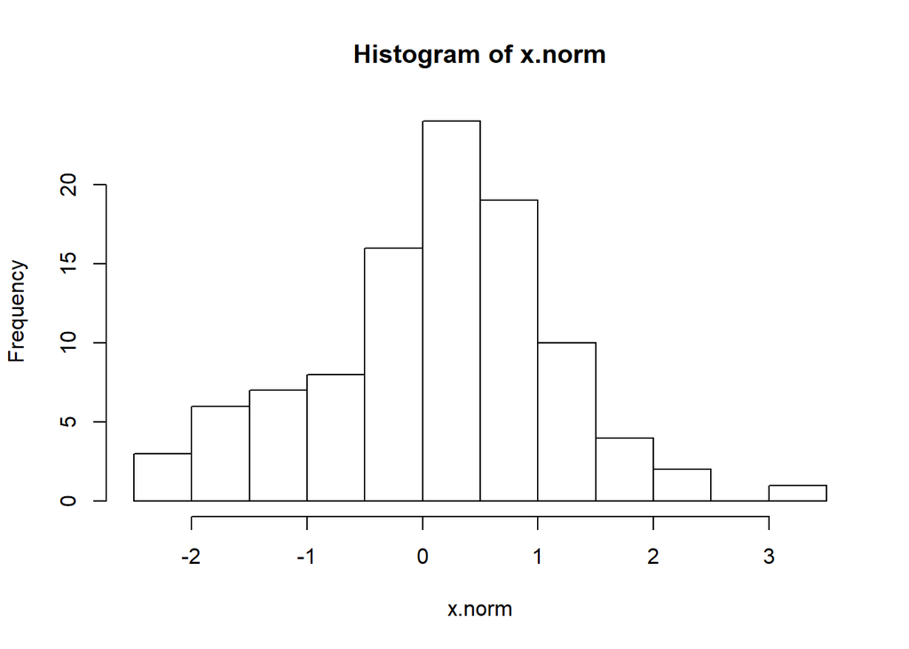

```r
x.norm<-rnorm(100,mean=0,sd=1)
hist(x.norm)
```

2. boxplot(x) ## boxplot 盒形圖

- for one chategory

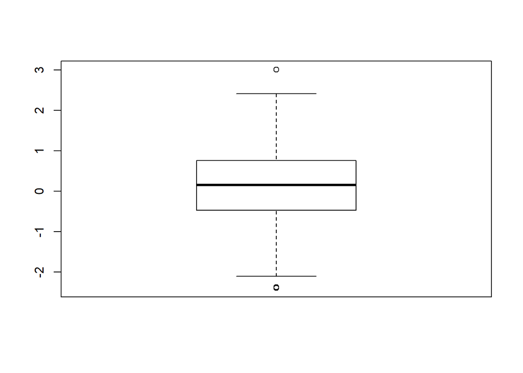

```r
boxplot(x.norm)
```

- for multiple categories

(use matrix)

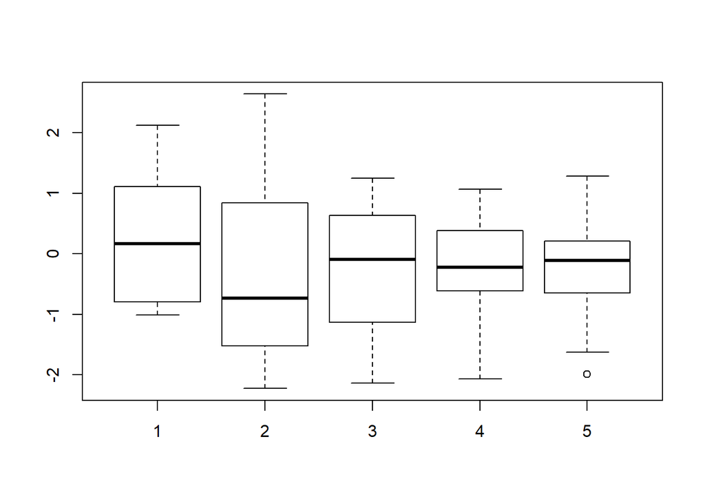

```r
xx<-matrix(rnorm(50),10,5)
boxplot(xx)
```

(use dataframe)

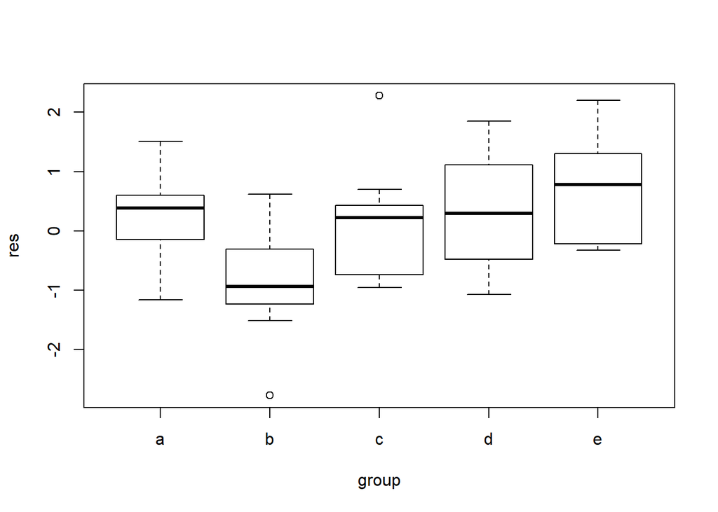

```r
xx<-data.frame(group=rep(c("a","b","c","d","e"),each=10),res=rnorm(50))
boxplot(res~group,xx) ##依group為依據，將res的值分組
```

3. plot(density(x)) ## density plot

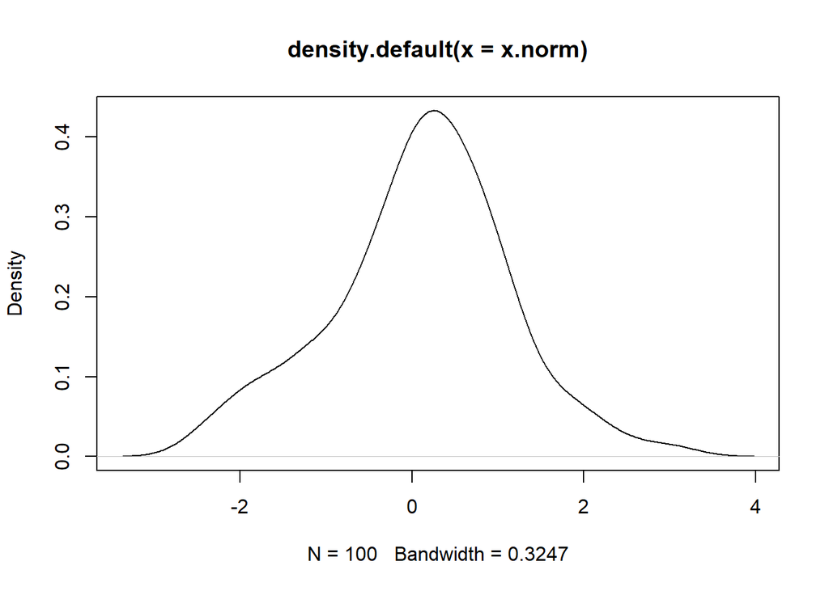

```r
plot(density(x.norm))
```

4. barplot(x) ## barchart 長條圖

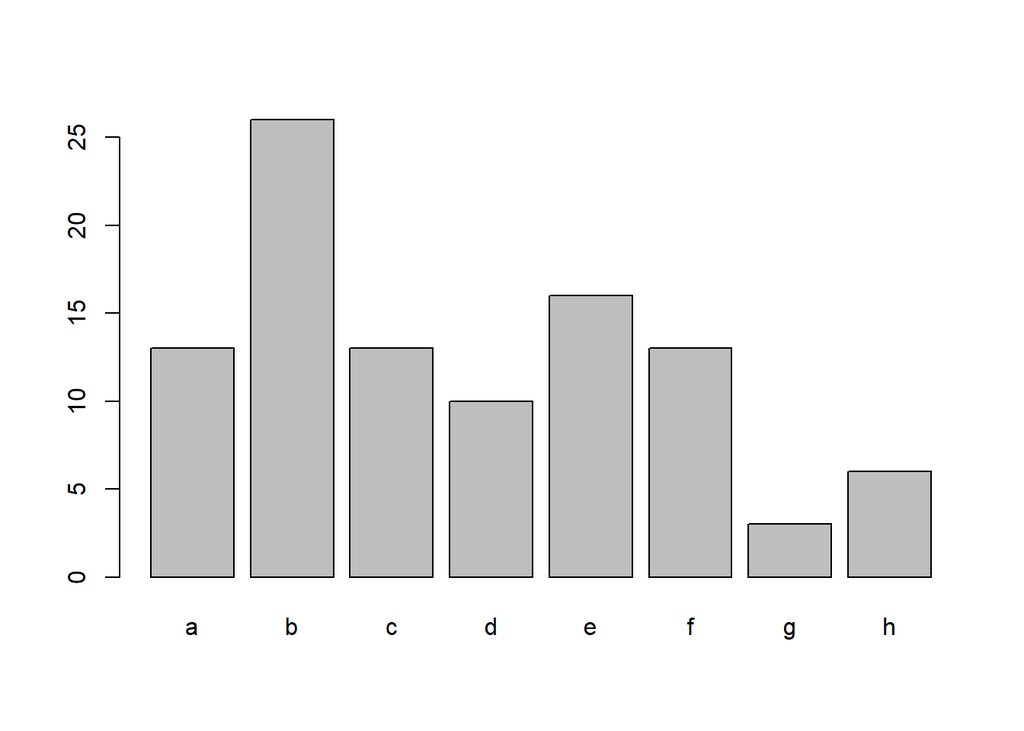

```r
x<-sample(c(1:8),100,replace=TRUE,prob=c(8:1))
x<-table(x)
names(x)<-c("a","b","c","d","e","f","g","h")
barplot(x)
```

5. pie(x) ## 圓餅圖

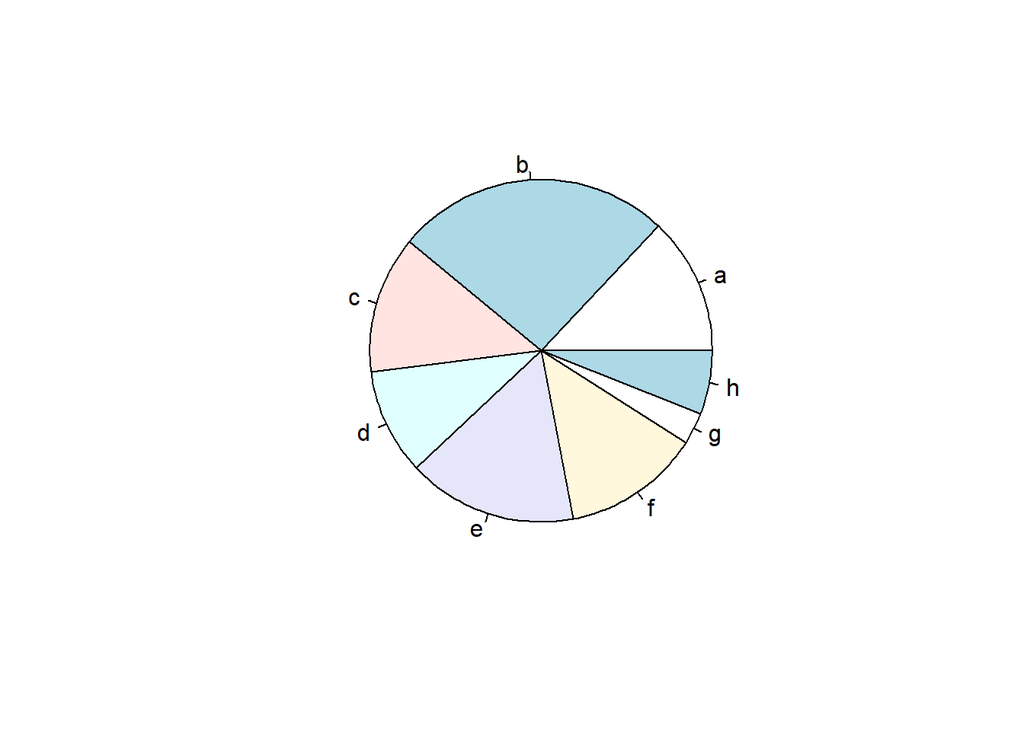

```r
pie(x)
```

6. curve(expression,from=…,to=…)

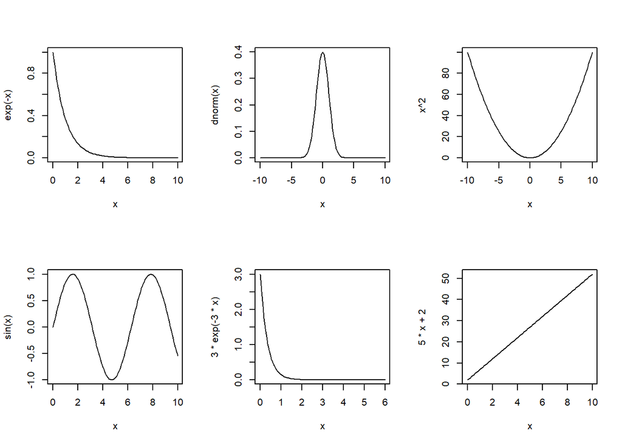

```r
par(mfrow=c(2,3))
curve(exp(-x),0,10)
curve(dnorm(x),-10,10)
curve(x^2,-10,10)
curve(sin,0,10)
curve(3*exp(-3*x),0,6)
curve(5*x+2,0,10)
```

7. scatter plot
- for one category：plot(x,y)

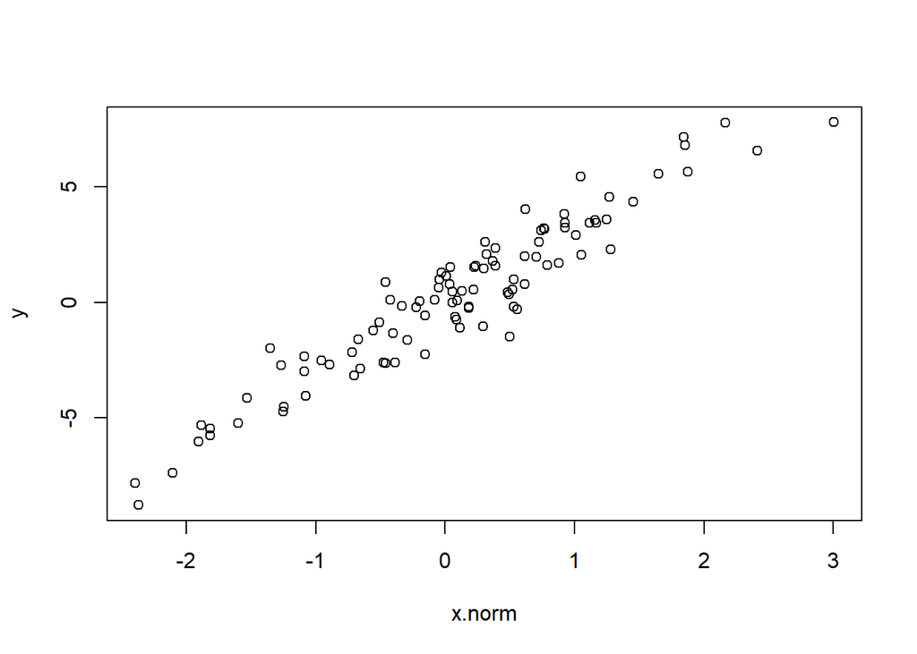

```r
y<-3*x.norm+rnorm(100,0,1)
plot(x.norm,y)
```

```r
cor(x.norm,y)
```

```
## [1] 0.951718
```

- for multiple categories：pairs(…) (ues matrix)

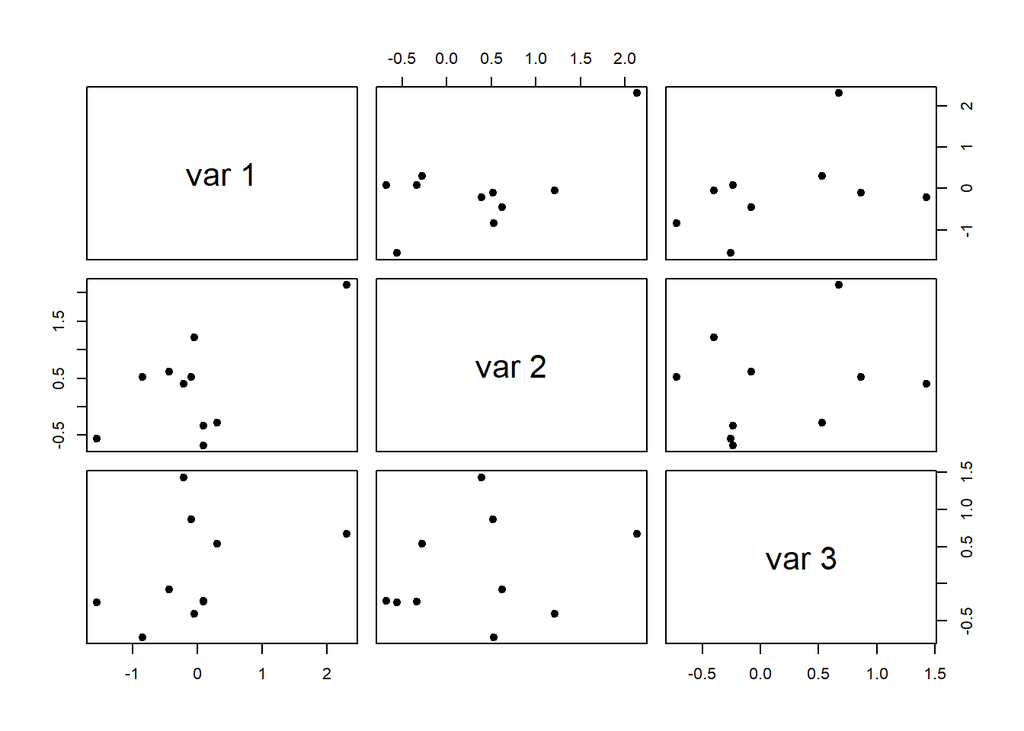

```r
xx<-matrix(rnorm(30),10,3)
pairs(xx,pch=19)
```

## ● scatter plot with specifical items

1. names of plot

**plot(…,main=…,sub=…,xlab=…,ylab=…)**

- main：上標題
- sub：下標題
- xlab：x軸名稱
- ylab：y軸名稱
2. **plot(…,type=…)**
- **“p”**：points
- **“l”**：lines
- **“b”**：points+lines
- **“o”**：lines pass through points
- **“h”**：the line between points and x-axis
- **“n”**：no content in the plot but plot region

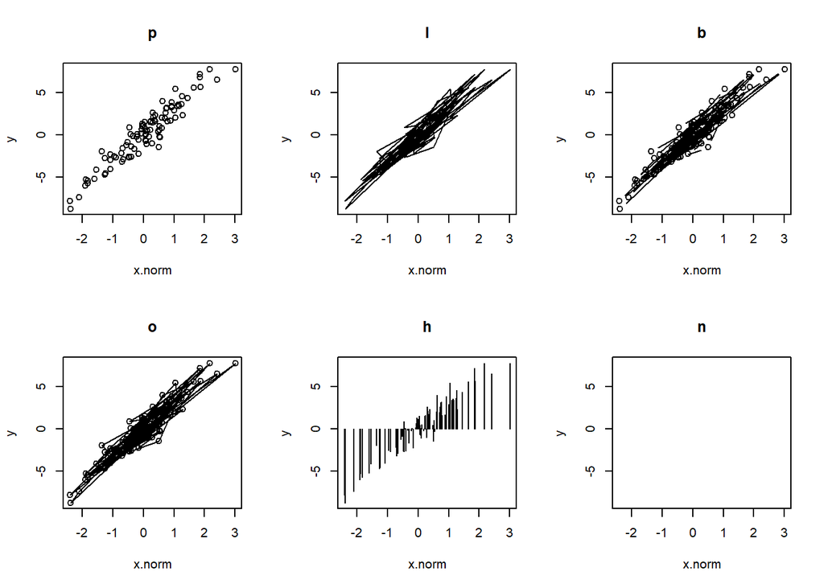

```r
par(mfrow=c(2,3)) ## split plot ranges
plot(x.norm,y,type="p",main="p")
plot(x.norm,y,type="l",main="l")
plot(x.norm,y,type="b",main="b")
plot(x.norm,y,type="o",main="o")
plot(x.norm,y,type="h",main="h")
plot(x.norm,y,type="n",main="n")
```

3. **plot(…,pch=…)**

[figure not shown]

4. **plot(…,cex=…)**
- size of points：**cex=1.5**
- size of title：**cex.main=2**
- size of labels of ticks of an axis：**cex.axis=2**
- size of labels of the name of an axis：**cex.lab=2**
5. **plot(…,type=“l”,lty=…,lwd=…)**

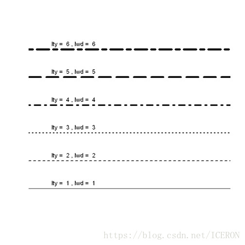

6. **plot(…,bty=…) ##box around the plot**
- **o**：complete box
- **n**：no box
- **7**：top & right
- **L**：bottom & left
- **C**：top & left & bottom
- **U**：left & bottom & right
7. **plot(…,col=…)**

$[use\ name]$：col=c(“red”,“green”,“blue”,“grey”)

8. **plot(…,xlim=…,ylim=…)**
- xlim=c(a,b)：$a<=x<=b$
- ylim=c(a,b)：$a<=y<=b$

## ● add some objects to the existing plot

   **text(x,y,labels=…)** ## 加字

   **legend(x,y,legend,…)** ##加legend

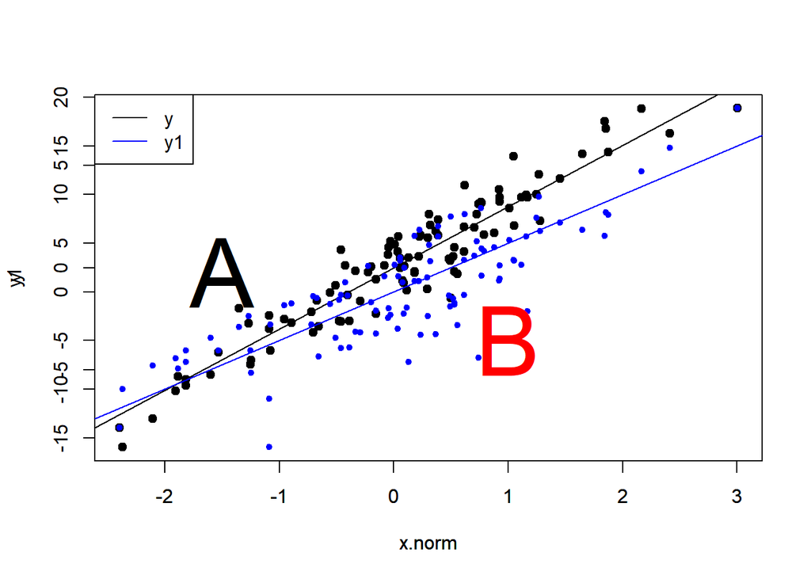

```r
y1<-5*x.norm+rnorm(50,0,3)

plot(x.norm,y,pch=19)
abline(a=0,b=3)
par(new=TRUE) ##不重新畫圖，直接把圖疊在上一個上面
plot(x.norm,y1,col=4,pch=20)
abline(a=0,b=5,col=4)

text(-1.5,2,"A",cex=5)
text(1,-5,"B",cex=5,col=2)
legend("topleft",c("y","y1"),col=c(1,4),lty=c(1,1))
```

5. layout()

   layout(matrix(c(1,2,3,3,4,5),3,2,byrow=TRUE))

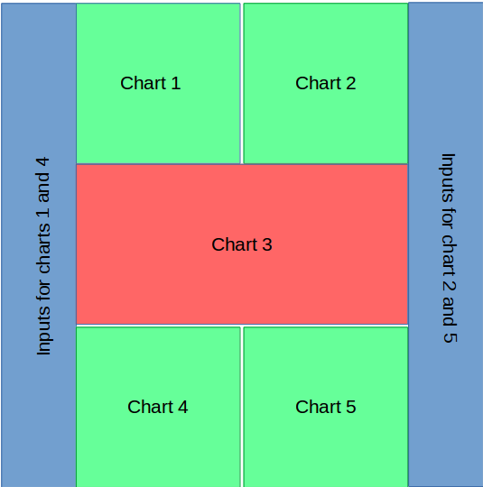

# IX. Rmarkdown

## ● equation

1. 輸入希臘字母(使用前要加 $\setminus$))

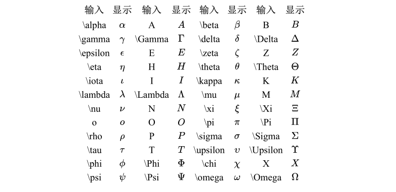

2. 插入公式

```r
#1 $...$
#2 $$...$$ (置中)
```

$x^2+y^2=1$
$$x^2+y^2=1$$

3. 輸入上下標

**^**表示上標，_表示下標。如果上下標內容多於一個字符，需要用{}將這些內容刮成一個整體

```r
## $$x^{y^z}=(1+{e^x})^{-2x{y^w}}$$
```

$$x^{y^z}=(1+{e^x})^{-2x{y^w}}$$

4. 輸入括號和分隔號

**()**、**[]**和**|**表示符號本身。當要顯示大括號或分隔號時要用$"\setminus left"$和$"\setminus right"$

```r
## $$f(x,y,z)=3y^2z\left(3+\frac{7x+5}{1+y^2}\right)$$
```

$$f(x,y,z)=3y^2z\left(3+\frac{7x+5}{1+y^2}\right)$$

```r
## $$\left.\frac{du}{dx}\right|_{x=0}$$
```

$$\left.\frac{du}{dx}\right|_{x=0}$$

5. 輸入分數

```r
##  \frac{分子}{分母}
```

6. 輸入開方

```r
##\sqrt{} (開平方根)；

##\sqrt[n]{x} (x開n次方)
```

```r
## $$\sqrt{5}\ and \sqrt[n]{3}$$
```

$$\sqrt{5}\ and \sqrt[n]{3}$$

7. 輸入累加、累乘運算

   _{下標}^{上標}{function} 累加

   _{下標}^{上標}{function} 累乘

$$\sum_{i=1}^{n}{\frac{1}{i^2}}$$
$$\prod_{i=1}^{n}{\frac{1}{i^2}}$$

8. 輸入戴帽符號

```r
## \hat{x}
```

$\hat{x}$

```r
## \bar{x}
```

$\bar{x}$

## ● table

```r
##Table Header | Second Header (是直的|，不是/)
##-------------|---------------
##Table Cell   | Cell 2
##Cell 3       | Cell 4
```

| Table Header | Second Header |
| --- | --- |
| Table Cell | Cell 2 |
| Cell 3 | Cell 4 |

## ● matrix

```r
#$\left[
#    \begin{array}{cc} ##{cc}置中
#      A & B \\        ## 兩個斜線\\代表換行
#      C & D \\
#    \end{array}
#  \right]$
```

$\left[ \begin{array}{cc} A & B \\ C & D \\ \end{array} \right]$

# X. Apply family

## ● apply()

apply(X,Margin,Fun)

- X：array or matrix (or a data frame)
- Margin：for a matrix 1 indicates rows,2 indicates columns
- Fun：name of a function

```r
A<-matrix(rnorm(1500),500,3)
apply(A,1,sum) ##(=rowSums)
```

[output not shown]

[output cut: 85 more lines]

```r
apply(A,2,sum) ##(=colSums)
```

```
## [1] -8.758631 17.358811  3.904389
```

## ● lapply()

lapply(X,Fun)

- X：vector or data frame or list
- Fun：name of a function
- return a list

```r
c<-list(a=1:10,beta=exp(-3:3))
lapply(c,mean) ##(=apply(c,mean))
```

```
## $a
## [1] 5.5
##
## $beta
## [1] 4.535125
```

## ● sapply()

sapply(X,Fun,…,simplify=TRUE)

```r
sapply(c,summary)
```

```
##             a        beta
## Min.     1.00  0.04978707
## 1st Qu.  3.25  0.25160736
## Median   5.50  1.00000000
## Mean     5.50  4.53512523
## 3rd Qu.  7.75  5.05366896
## Max.    10.00 20.08553692
```

```r
sapply(c,summary,simplify=FALSE)
```

```
## $a
##    Min. 1st Qu.  Median    Mean 3rd Qu.    Max.
##    1.00    3.25    5.50    5.50    7.75   10.00
##
## $beta
##     Min.  1st Qu.   Median     Mean  3rd Qu.     Max.
##  0.04979  0.25161  1.00000  4.53512  5.05367 20.08554
```

```r
lapply(c,summary)
```

```
## $a
##    Min. 1st Qu.  Median    Mean 3rd Qu.    Max.
##    1.00    3.25    5.50    5.50    7.75   10.00
##
## $beta
##     Min.  1st Qu.   Median     Mean  3rd Qu.     Max.
##  0.04979  0.25161  1.00000  4.53512  5.05367 20.08554
```

# 補充

1. set.seed(123456)
2. sample(1:6,1)/sample(1:6,2,replace=FALSE,prob=NULL)
3. runif(100) ##隨機產生100個uniform
4. rnorm(100,mean=0,sd=1) ##隨機產生100數符合常態平均為0,標準差為1